# PRS BrainAge

Jorge Garcia Condado

2025-06-11

# Polygenetic Risk Score of BrainAge

To examine the association between genetic predisposition to accelerated brain aging—measured by polygenic risk scores (PRS) derived from BrainAge models—and plasma biomarkers of Alzheimer’s disease (AD), with attention to age and sex-specific effects.

## Cohort Demographics

Data form the A4/LEARN study was used. Plasma samples were processed by two different companies: Eli Lilly and Company (Lilly) to develop a pTau217 assay and Roche Diagnostic for testing of the Elecsys Robust Prototype Immunoassays.

```
##             GFAP
## pTau217        NA Measurment
##   NA            0       1014
##   Measurment  358        622
```

| **Characteristic** | **Overall** N = 1,994<sup>1</sup> | **AB-**, N = 1205<sup>1</sup> | **AB+**, N = 789<sup>1</sup> | **p-value**<sup>2</sup> |
| --- | --- | --- | --- | --- |
| Age | 71.45 (4.79) | 71.13 (4.74) | 71.95 (4.81) | <0.001 |
| Sex |  |  |  | 0.8 |
| Female | 1,181 (59.23%) | 716 (59.42%) | 465 (58.94%) |  |
| Male | 813 (40.77%) | 489 (40.58%) | 324 (41.06%) |  |
| Education (Years) | 16.70 (2.69) | 16.73 (2.71) | 16.65 (2.66) | 0.7 |
| e4 |  |  |  | <0.001 |
| e4- | 1,218 (61.08%) | 913 (75.77%) | 305 (38.66%) |  |
| e4+ | 776 (38.92%) | 292 (24.23%) | 484 (61.34%) |  |
| Lilly Platform (N) | 980 (49.15%) | 243 (20.17%) | 737 (93.41%) | <0.001 |
| pTau217 (U/mL)<sup>3</sup> | 0.26 (0.14) | 0.17 (0.05) | 0.29 (0.15) | <0.001 |
| Roche Platform (N) | 1,636 (82.05%) | 1,185 (98.34%) | 451 (57.16%) | <0.001 |
| NfL (pg/mL)<sup>4</sup> | 3.26 (1.56) | 3.20 (1.53) | 3.41 (1.65) | 0.005 |
| GFAP (ng/mL)<sup>4</sup> | 0.10 (0.05) | 0.10 (0.05) | 0.12 (0.06) | <0.001 |

<sup>1</sup> Mean (SD); n (%)  
<sup>2</sup> Wilcoxon rank sum test; Pearson’s Chi-squared test  
<sup>3</sup> Lilly Clinical Diagnostics Laboratory conducted pTau217 testing using an automated electrochemiluminescent immunoassay (Tecan Fluent workstation for preparation, MSD Sector S Imager 600MM for detection)  
<sup>4</sup> Roche Diagnostics conducted testing of their Elecsys Robust Prototype Immunoassays.

## Distribution of PRS Z-scores

PRS were computed for three BrainAge models—Grey Matter (GM), White Matter (WM), and Functional Connectivity (FC)—using GWAS summary statistics from [Wen et al., 2024](https://www.nature.com/articles/s41467-024-46796-6).

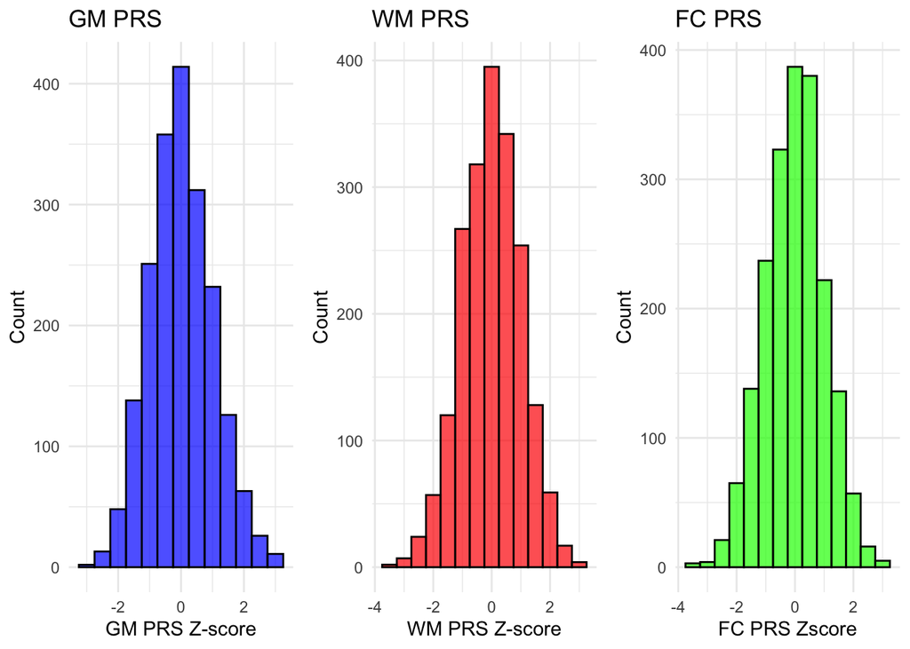

# Group analysis

Difference in PRS scores for different covariates.

## Sex

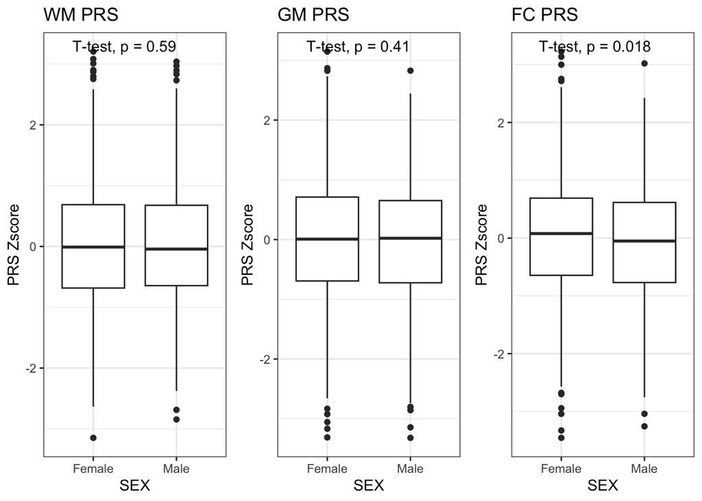

## E4 Status

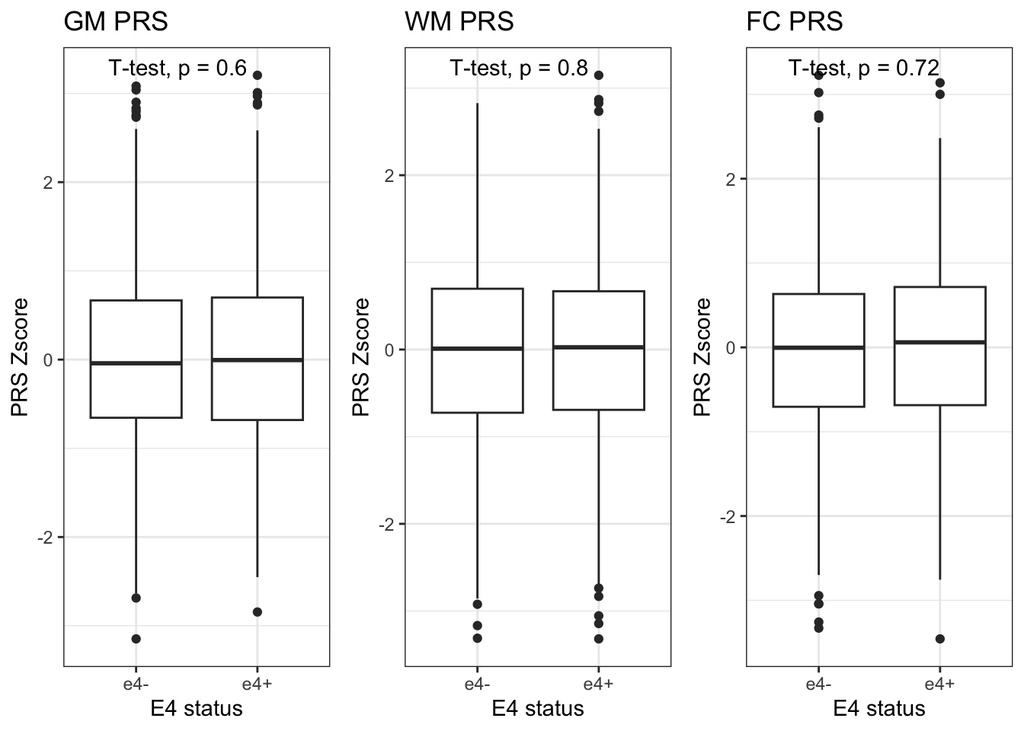

## Amyloid Status

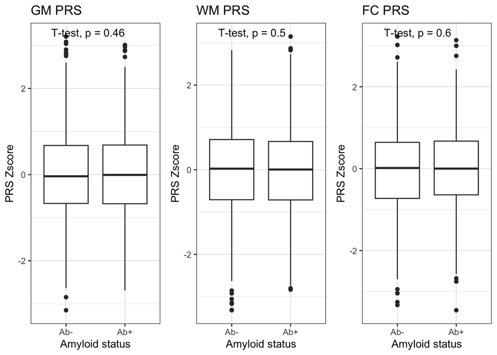

## Age

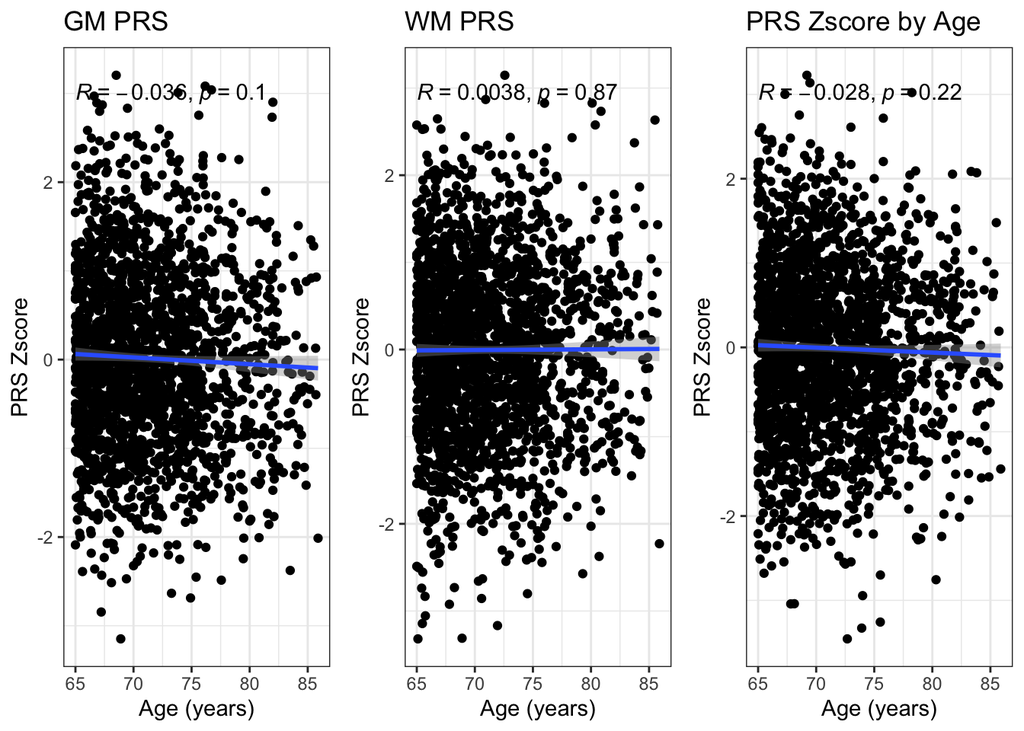

## Education

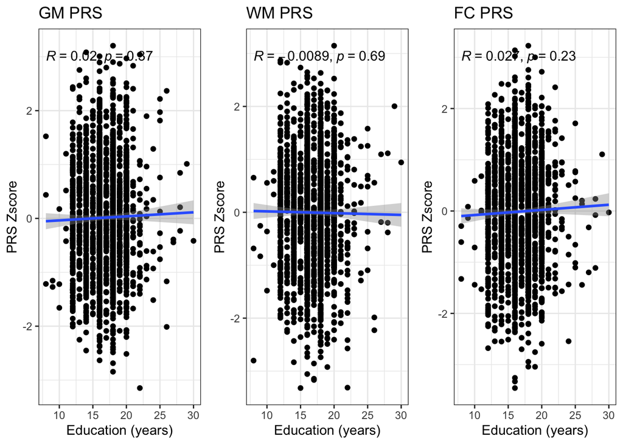

# General Linear Models for plasma biomaker

We build a general linear model that predicts plasma biomarkers using PRS, Age and PRS*Age interaction

## pTau217

```
## pTau217 GM PRS
```

```
## Standardized Effect GM PRS * Age:  0.08528101 p-val 0.008625942 Standard Error 0.03240335
```

```
## Standardized Effect GM PRS:  0.04007966 p-val 0.2006848 Standard Error 0.03130079
```

```
## Standardized Effect Age:  0.1932391 p-val 9.976846e-10 Standard Error 0.03131774
```

```
## pTau217 WM PRS
```

```
## Standardized Effect WM PRS * Age:  -0.002004517 p-val 0.9486958 Standard Error 0.03114478
```

```
## Standardized Effect WM PRS:  0.0132224 p-val 0.6744072 Standard Error 0.03146441
```

```
## Standardized Effect Age:  0.1891843 p-val 2.611081e-09 Standard Error 0.03147617
```

```
## pTau217 FC PRS
```

```
## Standardized Effect FC PRS * Age:  -0.01841823 p-val 0.5720494 Standard Error 0.03258555
```

```
## Standardized Effect FC PRS:  -0.02232357 p-val 0.4816408 Standard Error 0.03171252
```

```
## Standardized Effect Age:  0.1898933 p-val 2.137698e-09 Standard Error 0.03141876
```

## GFAP

```
## GFAP GM PRS
```

```
## Standardized Effect GM PRS * Age:  0.01475134 p-val 0.5302688 Standard Error 0.0234995
```

```
## Standardized Effect GM PRS:  0.03474877 p-val 0.1388101 Standard Error 0.02346367
```

```
## Standardized Effect Age:  0.3215882 p-val 1.718986e-40 Standard Error 0.02348222
```

```
## GFAP WM PRS
```

```
## Standardized Effect WM PRS * Age:  0.005952861 p-val 0.795151 Standard Error 0.0229247
```

```
## Standardized Effect WM PRS:  0.01852244 p-val 0.4297661 Standard Error 0.02345241
```

```
## Standardized Effect Age:  0.319316 p-val 4.870933e-40 Standard Error 0.02346115
```

```
## GFAP FC PRS
```

```
## Standardized Effect FC PRS * Age:  -0.003969956 p-val 0.8674005 Standard Error 0.02377395
```

```
## Standardized Effect FC PRS:  0.04309927 p-val 0.06704921 Standard Error 0.02351853
```

```
## Standardized Effect Age:  0.3210464 p-val 1.826968e-40 Standard Error 0.02345111
```

## NFL

```
## NF.L GM PRS
```

```
## Standardized Effect GM PRS * Age:  -0.001013195 p-val 0.9653824 Standard Error 0.02334172
```

```
## Standardized Effect GM PRS:  0.03674992 p-val 0.1150272 Standard Error 0.02330612
```

```
## Standardized Effect Age:  0.3394055 p-val 3.399259e-45 Standard Error 0.02332455
```

```
## NF.L WM PRS
```

```
## Standardized Effect WM PRS * Age:  0.02377836 p-val 0.2962756 Standard Error 0.02275902
```

```
## Standardized Effect WM PRS:  0.0254495 p-val 0.2745311 Standard Error 0.02328291
```

```
## Standardized Effect Age:  0.3371978 p-val 8.862141e-45 Standard Error 0.0232916
```

```
## NF.L FC PRS
```

```
## Standardized Effect FC PRS * Age:  0.02231588 p-val 0.3448377 Standard Error 0.0236166
```

```
## Standardized Effect FC PRS:  0.03593103 p-val 0.1242536 Standard Error 0.02336287
```

```
## Standardized Effect Age:  0.3393263 p-val 2.817249e-45 Standard Error 0.02329589
```

# Sensitivity analysis

We only find significant results when looking at pTau217 and the effect of GM BrainAge PRS.

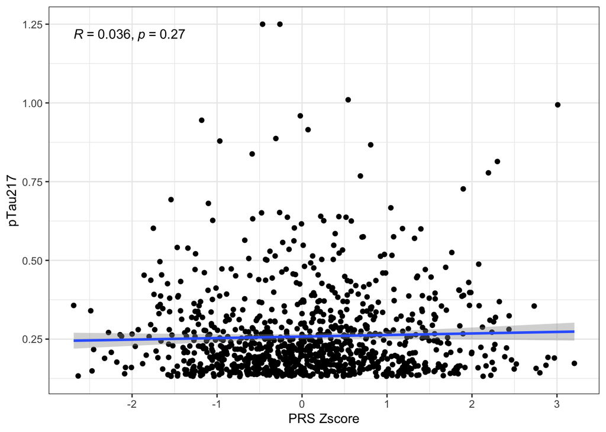

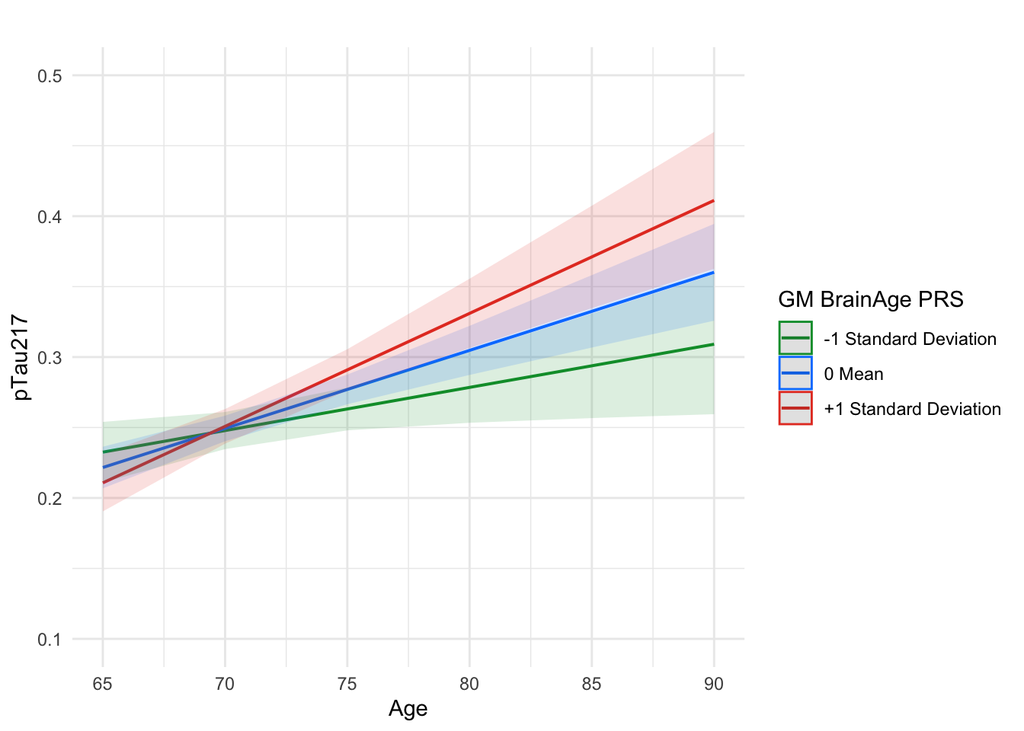

We investigate how adding the other PRS, covariates and other plasma biomarkers affects the results.

```
## Adding PRS
```

```
## Standardized Effect GM PRS * Age:  0.1420436 p-val 0.0005208807 Standard Error 0.04080006
```

```
## Standardized Effect GM PRS:  0.05544562 p-val 0.1456957 Standard Error 0.03807891
```

```
## Adding PRS and covariates
```

```
## Standardized Effect GM PRS * Age:  0.1334951 p-val 0.0005000295 Standard Error 0.03822264
```

```
## Standardized Effect GM PRS:  0.05906962 p-val 0.09886009 Standard Error 0.03575656
```

```
## Adding PRS, covariates and other blood biomarkers
```

```
## Standardized Effect GM PRS * Age:  0.08361205 p-val 0.04573155 Standard Error 0.04176486
```

```
## Standardized Effect GM PRS:  0.0825572 p-val 0.041583 Standard Error 0.04042967
```

We also train the model for different thresholds of the PRS. The results are shown in the table below.

```
## SUMMARY OF RESULTS ACROSS THRESHOLDS
```

```
##   threshold GM_age_beta GM_age_pval
## 1     0.001      0.0737      0.0229
## 2     0.050      0.0946      0.0036
## 3     0.100      0.0943      0.0034
## 4     0.200      0.0849      0.0086
## 5     0.300      0.0861      0.0075
## 6     0.400      0.0880      0.0066
## 7     0.500      0.0865      0.0077
```

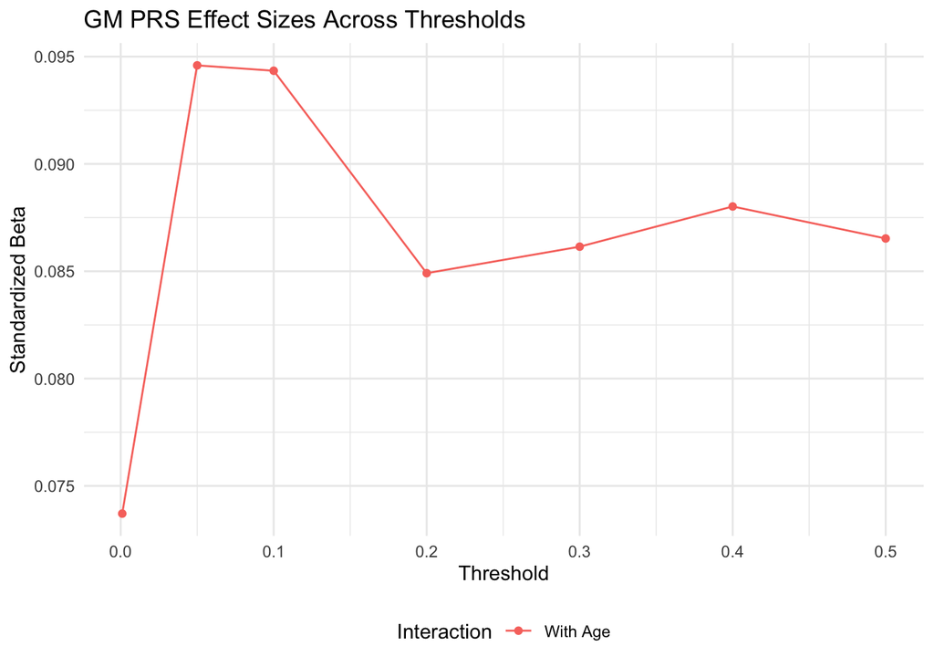

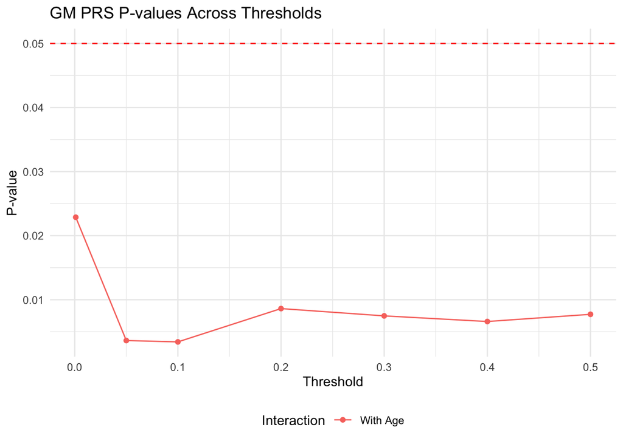

# Sex differences

## Sex interaction

```
## Adding GM PRS x Age X Sex interaction
```

```
## Standardized Effect GM PRS * Age * Sex:  -0.04630721 p-val 0.4761373 Standard Error 0.06496473
```

```
## Standardized Effect GM PRS * Age:  0.1069317 p-val 0.01597901 Standard Error 0.04430347
```

```
## Standardized Effect Age * SEX:  0.05491144 p-val 0.3849806 Standard Error 0.06317846
```

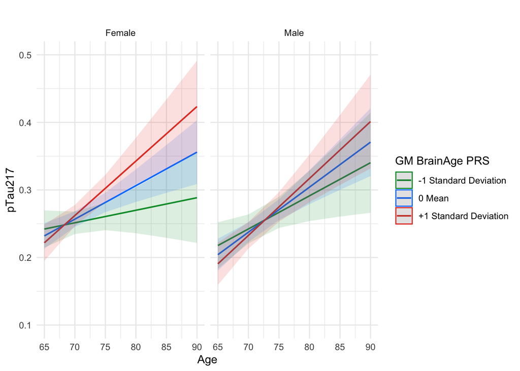

## Startified sex models

### Male

```
## Male only model
```

```
## Standardized Effect GM PRS * Age:  0.06969601 p-val 0.1398278 Standard Error 0.04711139
```

```
## Standardized Effect GM PRS:  -0.007886787 p-val 0.8701642 Standard Error 0.04822089
```

```
## Standardized Effect Age: 0.2743852 p-val 2.235873e-08 Standard Error 0.04806957
```

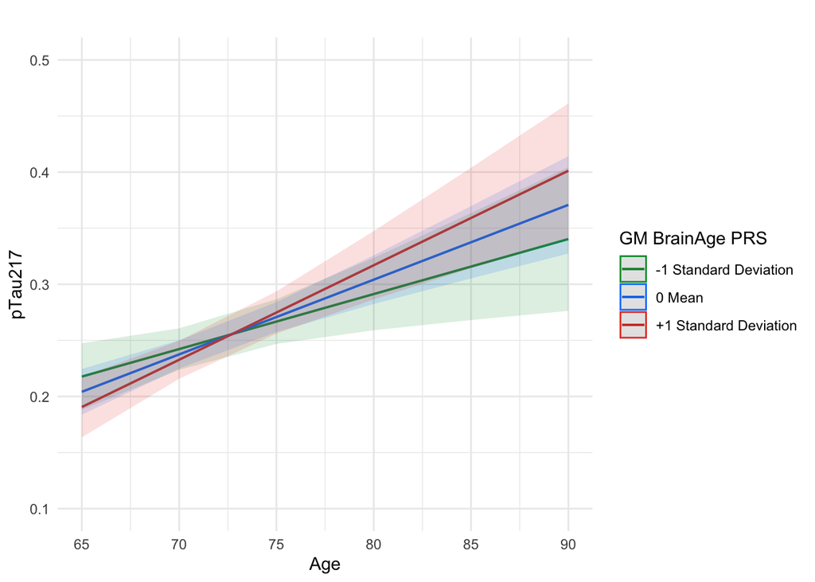

### Female

```
## Female only model
```

```
## Standardized Effect GM PRS * Age:  0.0977974 p-val 0.02652551 Standard Error 0.04397037
```

```
## Standardized Effect GM PRS:  0.06402584 p-val 0.1193791 Standard Error 0.04104979
```

```
## Standardized Effect Age: 0.1555431 p-val 0.0001707727 Standard Error 0.04110928
```

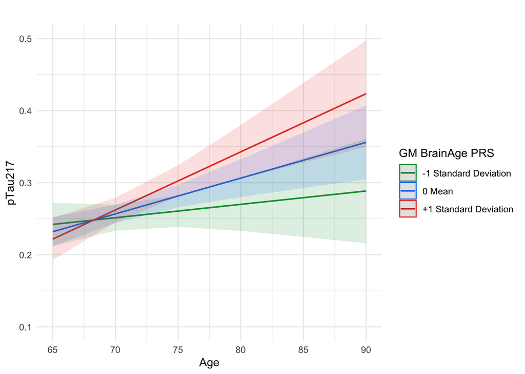

## Senstivity analysis

Matching Female and Male subjects on Age, Years of Education, APOEe4 and Amyloid

```
## Male only model
```

```
## Standardized Effect GM PRS * Age:  0.06969601 p-val 0.1398278
```

```
## Standardized Effect Age: 0.2743852 p-val 2.235873e-08
```

```
## Female only model
```

```
## Standardized Effect GM PRS * Age:  0.1046526 p-val 0.050053
```

```
## Standardized Effect Age: 0.190101 p-val 0.0001278177
```